# Title: Analyzing Media: What Makes Movies Popular?

Group Name: Rebecca Silberman and Raynah Jacobs

**Project Goal:** As we are both fascinated by media, we want to investigate what makes movies popular. Our goal is to investigate the factors, such as budget, running time, and genre, that contribute to a movie's success in the box office as ticket sales. Through identityfing patterns in the IMDb scores, Oscars and Golden Globe Nominations, Oscars and Golden Globe Awards, budget, genre, and running time, we will determine which elements have an impact on a film's popularity. Ultimately, this analysis will help us understand which factors consistently lead to box office success.

**Description of Dataset:** Our dataset comes from Kaggle.com. The dataset we chose is titled, Movies (IMDb, Earnings and more). This dataset includes the rows: movie (name of film), director (film director), running time (length of time in minutes of movie), actor 1, actor 2, actor 3, genre (category of film), budget (money spent on making the movie and its publicity), box office (money from ticket sales), actors box office % (percentage that reflects how many times the actors managed to at least double the budget in their other films movies), director box office % (percentage that reflects how many times the director managed to at least double the budget in their other films movies), earnings (difference between box office and budget), oscars and golden globe nominations (amount of nominations that the movie has in the oscars and golden globes), oscars and golden globe awards (amount of awards that the movie had in the oscars and the golden globes), release year, and IMDb score (score out of 10 that is calculated from the votes of registers IMDb users on the movie). This data can help us answer which factors contribute to a movie's success and popularity. We plan on utilizing the data on the movie title, running time, genre, budget, Oscars and Golden Globe nominations and awards, and IMDb scores to determine which factors affect the box office money from ticket sales the most significantly.

**Collaboration Plan:** Our collaboration plan is for Rebecca to be responsible for the ETL section and for Raynah to be responsible for the EDA section of milestone 1. Together, we will make conclusions based on our findings and visualizations.

## ETL

```python
from google.colab import drive
drive.mount('/content/drive')
```

```python
from google.colab import files
uploaded = files.upload()
```

```
Saving movies_data.csv to movies_data.csv
```

```python
# Load the dataset
import pandas as pd
file_path = "/content/movies_data.csv"
df = pd.read_csv(file_path, encoding = 'latin-1')
df.head()
```

|  | Movie | Director | Running time | Actor 1 | Actor 2 | Actor 3 | Genre | Budget | Box Office | Actors Box Office % | Director Box Office % | Earnings | Oscar and Golden Globes nominations | Oscar and Golden Globes awards | Release year | IMDb score |
| --- | --- | --- | --- | --- | --- | --- | --- | --- | --- | --- | --- | --- | --- | --- | --- | --- |
| 0 | 13 Hours | Michael Bay | 144 | Toby Stephens | James Badge Dale | David Costabile | Action | 50000000 | 69400000 | 50.00 | 69.23 | 19400000 | 0 | 0.0 | 2016 | 7.4 |
| 1 | 16 Blocks | Richard Donner | 102 | Bruce Willis | David Zayas | Sasha Roiz | Action | 52000000 | 65000000 | 33.33 | 50.00 | 13000000 | 0 | 0.0 | 2006 | 6.6 |
| 2 | 17 Again | Burr Steers | 102 | Matthew Perry | Hunter Parrish | Thomas Lennon | Comedy | 20000000 | 139000000 | 44.44 | 25.00 | 119000000 | 0 | 0.0 | 2009 | 6.4 |
| 3 | 1982 | Tommy Oliver | 90 | Bokeem Woodbine | Ruby Dee | Quinton Aaron | Drama | 1000000 | 2000000 | 50.00 | 100.00 | 1000000 | 0 | 0.0 | 2013 | 7.1 |
| 4 | 2 Fast 2 Furious | John Singleton | 107 | Paul Walker | Cole Hauser | Mo Gallini | Action | 76000000 | 236000000 | 75.00 | 42.85 | 160000000 | 0 | 0.0 | 2003 | 5.9 |

**What is this data?** This dataset contains information about movies including their financial performance (budget, box office earnings), roles (actors, director), critics (IMDb score, awards), and general details (running time, release year, genre).

**How can it be used to answer the question?** We can determine whether certain factors, such as a certain genre, large budget, correlate with a movie's financial success in the box office and critical success in awards and IMDb scores.

**Where is the data from?** The data comes from Kaggle, an online community for data scientists and machine learners. The link to where I found the dataset is: https://www.kaggle.com/datasets/delfinaoliva/movies?resource=download.

**How is the data collected?** The data in this dataset has been collected from various public databases that provide access to IMDb information, Oscars/Golden Globe reports, box office earning accounts, and other various data sources on public files like GitHub, remote URLs, and Notebook output folders.

```python
# Tidy the dataset
df_selected = df[['Movie', 'Director', 'Genre', 'Running time','Budget', 'IMDb score', 'Oscar and Golden Globes nominations', 'Oscar and Golden Globes awards', 'Box Office', 'Earnings']]
df_tidy = df_selected.melt()
df_tidy.head()
```

|  | variable | value |
| --- | --- | --- |
| 0 | Movie | 13 Hours |
| 1 | Movie | 16 Blocks |
| 2 | Movie | 17 Again |
| 3 | Movie | 1982 |
| 4 | Movie | 2 Fast 2 Furious |

```python
# Set and display data types
#df_selected['Oscar and Golden Globes awards'] = df_selected['Oscar and Golden Globes awards'].fillna(0).astype(int)
df_selected.dtypes
```

|  | 0 |
| --- | --- |
| Movie | object |
| Director | object |
| Genre | object |
| Running time | int64 |
| Budget | int64 |
| IMDb score | float64 |
| Oscar and Golden Globes nominations | int64 |
| Oscar and Golden Globes awards | float64 |
| Box Office | int64 |
| Earnings | int64 |

**dtype:** object

## EDA

For our project, we're hoping to determine what factors (looking at budget and running time) have the biggest influence on a movie's success. Our dataset measures a couple different variables that could be used to measure "success." There is box office performance, Oscar and Golden Globe Nominations, IMDb score and Earnings. We will infer which factors, if any, has a substantial impact on a film's success by measuring the correlation between a film's budget and running time and its box office performance, award show nominations, IMDb score and earnings. Considering these are all quantitative variables, we thought it would make the most sense to meausure the relationship between these variables using the correlation function.

```python
display(df["Budget"].corr(df["Box Office"]))
display(df["Budget"].corr(df["Oscar and Golden Globes nominations"]))
display(df["Budget"].corr(df["Earnings"]))
display(df["Budget"].corr(df["IMDb score"]))
```

```
0.7070662892927986
```

```
0.013439087594017298
```

```
0.55320805595872
```

```
0.023947702931129834
```

```python
display(df["Running time"].corr(df["Box Office"]))
display(df["Running time"].corr(df["Oscar and Golden Globes nominations"]))
display(df["Running time"].corr(df["Earnings"]))
display(df["Running time"].corr(df["IMDb score"]))
```

```
0.26535705424463063
```

```
0.3523013134699673
```

```
0.23397094858222753
```

```
0.3628772685182314
```

Above, we found the correlation between a movie's run time and its box office performance, run time and it's Oscar and Golden Globes nominations, run time and the movie's earnings, and run time and the movie's IMBd score. As mentioned above, we are looking at the correlation between the movie's run time and multiple other variables because we have not yet decided which variable we will ultimately use to determine the movie's "success."

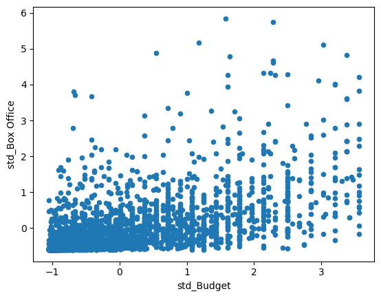

```python
df['std_Box Office'] = (df['Box Office'] - df['Box Office'].mean()) / df['Box Office'].std()

threshold = df['Budget'].quantile(0.95)
df = df[df['Budget'] <= threshold]
df['std_Budget'] = (df['Budget'] - df['Budget'].mean()) / df['Budget'].std()

df.plot.scatter(x='std_Budget', y='std_Box Office')
```

```python
display(df["Budget"].cov(df["Box Office"]))
```

```
2067354936247383.0
```

```python
ls -lah "/content/drive/My Drive/Colab Notebooks/"
```

[output not shown]

```python
ls -lah /content/
```

[output not shown]

```python
%%shell
find / AnalyzingMedia:WhatMakesMoviesPopular.ipynd "*.ipynb" 2>/dev/null
```

[output not shown]

[output cut: 4946 more lines]

[output not shown]

[output not shown]

```python
%%shell
jupyter nbconvert --to html "/content/drive/My Drive/Colab Notebook.ipynb"
```

[output not shown]

[output cut: 136 more lines]

[output not shown]

[output not shown]